# Case Study: Predicting Airline Delays

# A review of regression

Which are the most correlated variables with Delay?

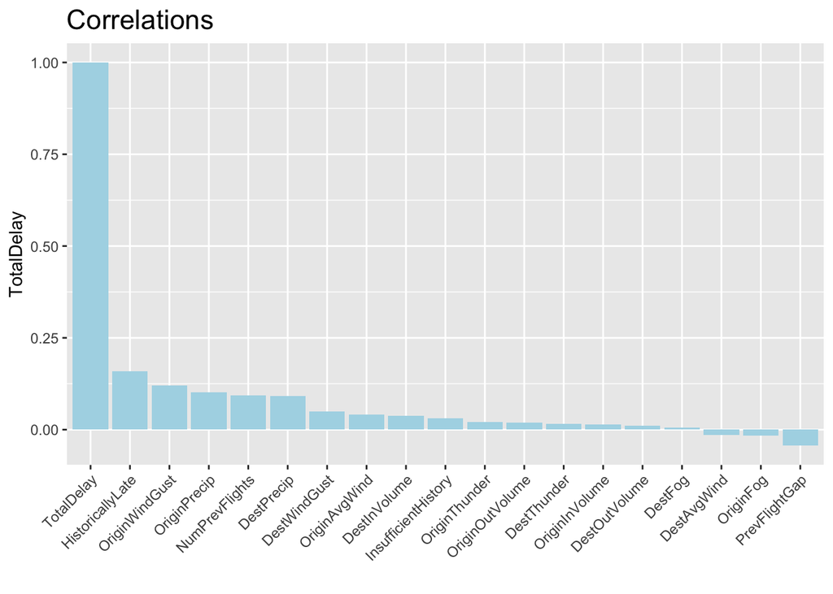

```r
corr_delay <- sort(cor(AirlinesTrain[,c(5:23)])["TotalDelay",], decreasing = T)
corr=data.frame(corr_delay)
ggplot(corr,aes(x = row.names(corr), y = corr_delay)) +
  geom_bar(stat = "identity", fill = "lightblue") +
  scale_x_discrete(limits= row.names(corr)) +
  labs(x = "", y = "TotalDelay", title = "Correlations") +
  theme(plot.title = element_text(hjust = 0, size = rel(1.5)),
        axis.text.x = element_text(angle = 45, hjust = 1))
```

Insights?

Simple regression: try first the most relevant predictor from previous analysis

```r
linFit <- lm(log(TotalDelay+10) ~ HistoricallyLate, data=AirlinesTrain)
summary(linFit)
```

```
##
## Call:
## lm(formula = log(TotalDelay + 10) ~ HistoricallyLate, data = AirlinesTrain)
##
## Residuals:
##     Min      1Q  Median      3Q     Max
## -1.2247 -0.5081 -0.3941  0.3901  3.8372
##
## Coefficients:
##                  Estimate Std. Error t value Pr(>|t|)
## (Intercept)       2.69671    0.01194  225.88   <2e-16 ***
## HistoricallyLate  0.96898    0.04251   22.79   <2e-16 ***
## ---
## Signif. codes:  0 '***' 0.001 '**' 0.01 '*' 0.05 '.' 0.1 ' ' 1
##
## Residual standard error: 0.7642 on 7504 degrees of freedom
## Multiple R-squared:  0.06475,    Adjusted R-squared:  0.06463
## F-statistic: 519.6 on 1 and 7504 DF,  p-value: < 2.2e-16
```

Insights?

### Prediction

```r
# Take care: output is in logs
predictions <- exp(predict(linFit, newdata=AirlinesTest))-10
cor(AirlinesTest$TotalDelay, predictions)^2
```

```
## [1] 0.03334081
```

Note the $R^2$ in the testing set is now less than that in the training set. Why?

### Multiple regression

If we include more variables in the model, the prediction accuracy could be improved

Try some multiple regression models and compute performance measures in the testing set

```r
linFit <- lm(log(TotalDelay+10) ~ ., data=AirlinesTrain)
summary(linFit)
```

```
##
## Call:
## lm(formula = log(TotalDelay + 10) ~ ., data = AirlinesTrain)
##
## Residuals:
##     Min      1Q  Median      3Q     Max
## -1.9130 -0.4793 -0.1880  0.3652  3.8581
##
## Coefficients:
##                              Estimate Std. Error t value Pr(>|t|)
## (Intercept)                 1.280e+00  1.635e-01   7.827 5.67e-15 ***
## FlightATL-ORD              -1.051e-02  3.571e-02  -0.294 0.768540
## FlightLAX-ATL              -3.359e-02  3.225e-02  -1.041 0.297746
## FlightLAX-ORD              -2.577e-01  2.203e-01  -1.170 0.242161
## FlightORD-ATL               8.471e-03  3.736e-02   0.227 0.820619
## FlightORD-LAX              -1.400e-01  2.203e-01  -0.635 0.525208
## CarrierAmerican Airlines    2.712e-01  2.265e-01   1.197 0.231252
## CarrierDelta Air Lines      2.639e-02  5.656e-02   0.467 0.640797
## CarrierExpressJet Airlines  1.804e-01  1.054e-01   1.711 0.087051 .
## CarrierSkyWest Airlines     2.760e-01  7.877e-02   3.504 0.000460 ***
## CarrierSouthwest Airlines   7.366e-03  6.332e-02   0.116 0.907401
## CarrierUnited Airlines      4.082e-01  2.252e-01   1.813 0.069941 .
## CarrierVirgin America       2.477e-01  2.300e-01   1.077 0.281431
## MonthJuly                  -1.195e-01  2.109e-02  -5.666 1.51e-08 ***
## MonthJune                  -3.362e-02  2.187e-02  -1.537 0.124295
## DayOfWeekMonday             8.100e-04  3.125e-02   0.026 0.979322
## DayOfWeekSaturday          -7.056e-02  3.349e-02  -2.107 0.035153 *
## DayOfWeekSunday            -1.051e-01  3.161e-02  -3.324 0.000892 ***
## DayOfWeekThursday           6.479e-02  3.140e-02   2.063 0.039139 *
## DayOfWeekTuesday           -2.854e-02  3.238e-02  -0.881 0.378088
## DayOfWeekWednesday          6.309e-02  3.160e-02   1.996 0.045919 *
## NumPrevFlights              2.559e-02  8.169e-03   3.133 0.001738 **
## PrevFlightGap              -8.954e-05  1.323e-04  -0.677 0.498456
## HistoricallyLate            1.330e+00  5.403e-02  24.610  < 2e-16 ***
## InsufficientHistory         3.915e-01  2.606e-02  15.022  < 2e-16 ***
## OriginInVolume              6.896e-02  7.842e-02   0.879 0.379195
## OriginOutVolume             3.734e-01  1.027e-01   3.634 0.000281 ***
## DestInVolume                2.913e-01  1.043e-01   2.792 0.005247 **
## DestOutVolume               6.104e-02  3.761e-02   1.623 0.104705
## OriginPrecip                5.741e-04  1.035e-04   5.544 3.06e-08 ***
## OriginAvgWind              -1.130e-02  4.809e-03  -2.351 0.018769 *
## OriginWindGust              1.849e-02  2.158e-03   8.571  < 2e-16 ***
## OriginFog                   2.956e-02  2.705e-02   1.093 0.274461
## OriginThunder               4.273e-02  5.298e-02   0.807 0.419964
## DestPrecip                  7.588e-04  1.052e-04   7.210 6.13e-13 ***
## DestAvgWind                -1.535e-02  4.834e-03  -3.176 0.001498 **
## DestWindGust                1.223e-02  2.156e-03   5.672 1.46e-08 ***
## DestFog                    -3.554e-02  2.727e-02  -1.304 0.192444
## DestThunder                 1.322e-01  5.319e-02   2.486 0.012935 *
## ---
## Signif. codes:  0 '***' 0.001 '**' 0.01 '*' 0.05 '.' 0.1 ' ' 1
##
## Residual standard error: 0.7147 on 7467 degrees of freedom
## Multiple R-squared:  0.186,  Adjusted R-squared:  0.1819
## F-statistic:  44.9 on 38 and 7467 DF,  p-value: < 2.2e-16
```

Prediction:

```r
pred.log <- predict(linFit, newdata=AirlinesTest)
cor(log(AirlinesTest$TotalDelay+10), pred.log)^2
```

```
## [1] 0.1758848
```

Many variables non-significant: high collinearity, not useful to explain (overfitting)

But useful to predict: R2 is roughly 20% in the testing

Other performance measures: MAPE and RMSE

```r
# Error in percentage (mape):
MAPE = mean(abs(log(AirlinesTest$TotalDelay+10)- pred.log)/log(AirlinesTest$TotalDelay+10))
MAPE
```

```
## [1] 0.1866181
```

```r
# Testing residual standard-error:
RMSE <- sqrt(mean((pred.log - log(AirlinesTest$TotalDelay+10))^2))
RMSE
```

```
## [1] 0.730367
```

```r
# this is similar to the Residual standard error in summary(linFit) because units are in logs

# This is the RMSE in minutes:
sqrt(mean((predictions - AirlinesTest$TotalDelay)^2))
```

```
## [1] 40.95656
```

# Advanced regression models

A basic multiple regression model with interactions:

```r
linFit <- lm(log(TotalDelay+10) ~ OriginAvgWind + OriginPrecip + DestAvgWind + DestPrecip + HistoricallyLate +
               OriginPrecip:DestPrecip, data=AirlinesTrain)

summary(linFit)
```

```
##
## Call:
## lm(formula = log(TotalDelay + 10) ~ OriginAvgWind + OriginPrecip +
##     DestAvgWind + DestPrecip + HistoricallyLate + OriginPrecip:DestPrecip,
##     data = AirlinesTrain)
##
## Residuals:
##     Min      1Q  Median      3Q     Max
## -1.9361 -0.4949 -0.3135  0.3846  3.7382
##
## Coefficients:
##                           Estimate Std. Error t value Pr(>|t|)
## (Intercept)              2.389e+00  4.608e-02  51.856  < 2e-16 ***
## OriginAvgWind            2.267e-02  3.796e-03   5.973 2.44e-09 ***
## OriginPrecip             1.155e-03  1.003e-04  11.513  < 2e-16 ***
## DestAvgWind              9.668e-03  3.801e-03   2.543  0.01100 *
## DestPrecip               1.044e-03  1.015e-04  10.278  < 2e-16 ***
## HistoricallyLate         9.724e-01  4.190e-02  23.209  < 2e-16 ***
## OriginPrecip:DestPrecip -2.963e-06  1.129e-06  -2.624  0.00871 **
## ---
## Signif. codes:  0 '***' 0.001 '**' 0.01 '*' 0.05 '.' 0.1 ' ' 1
##
## Residual standard error: 0.7516 on 7499 degrees of freedom
## Multiple R-squared:  0.09599,    Adjusted R-squared:  0.09526
## F-statistic: 132.7 on 6 and 7499 DF,  p-value: < 2.2e-16
```

```r
pred.log <- predict(linFit, newdata=AirlinesTest)
cor(log(AirlinesTest$TotalDelay+10), pred.log)^2
```

```
## [1] 0.08197516
```

R2 in the training is 10%

R2 in the testing is around 10%

An even more advanced model using categorical variables: for instance, Flight has 6 categories but R creates 5 dummies, why?

Useful to incorporate interactions between categorical variables and numeric ones

```r
linFit <- lm(log(TotalDelay+10) ~ Flight*(OriginAvgWind+OriginPrecip+DestAvgWind+DestPrecip+OriginWindGust+HistoricallyLate)+I(HistoricallyLate^2)+OriginPrecip:DestPrecip, data=AirlinesTrain)
summary(linFit)
```

```
##
## Call:
## lm(formula = log(TotalDelay + 10) ~ Flight * (OriginAvgWind +
##     OriginPrecip + DestAvgWind + DestPrecip + OriginWindGust +
##     HistoricallyLate) + I(HistoricallyLate^2) + OriginPrecip:DestPrecip,
##     data = AirlinesTrain)
##
## Residuals:
##     Min      1Q  Median      3Q     Max
## -2.4309 -0.4841 -0.2391  0.3695  3.7718
##
## Coefficients:
##                                  Estimate Std. Error t value Pr(>|t|)
## (Intercept)                     2.150e+00  1.770e-01  12.151  < 2e-16 ***
## FlightATL-ORD                  -1.643e-02  2.193e-01  -0.075 0.940263
## FlightLAX-ATL                   4.387e-01  2.714e-01   1.616 0.106133
## FlightLAX-ORD                   9.918e-01  2.411e-01   4.114 3.93e-05 ***
## FlightORD-ATL                   6.172e-02  2.165e-01   0.285 0.775559
## FlightORD-LAX                   4.957e-01  2.312e-01   2.144 0.032031 *
## OriginAvgWind                   3.633e-03  1.037e-02   0.350 0.726154
## OriginPrecip                    9.885e-04  2.366e-04   4.178 2.98e-05 ***
## DestAvgWind                     2.430e-02  1.847e-02   1.316 0.188267
## DestPrecip                     -4.223e-03  5.909e-03  -0.715 0.474862
## OriginWindGust                  1.482e-02  3.982e-03   3.722 0.000199 ***
## HistoricallyLate               -2.707e-01  1.452e-01  -1.864 0.062293 .
## I(HistoricallyLate^2)           1.871e+00  1.656e-01  11.296  < 2e-16 ***
## FlightATL-ORD:OriginAvgWind     1.639e-02  1.584e-02   1.034 0.300938
## FlightLAX-ATL:OriginAvgWind    -1.565e-02  2.663e-02  -0.588 0.556854
## FlightLAX-ORD:OriginAvgWind     2.656e-03  2.365e-02   0.112 0.910584
## FlightORD-ATL:OriginAvgWind    -4.385e-02  1.630e-02  -2.689 0.007175 **
## FlightORD-LAX:OriginAvgWind    -3.196e-02  1.365e-02  -2.342 0.019203 *
## FlightATL-ORD:OriginPrecip     -1.634e-04  3.572e-04  -0.457 0.647384
## FlightLAX-ATL:OriginPrecip     -5.571e-03  5.493e-03  -1.014 0.310503
## FlightLAX-ORD:OriginPrecip      3.524e-04  4.775e-03   0.074 0.941171
## FlightORD-ATL:OriginPrecip      7.491e-05  3.333e-04   0.225 0.822186
## FlightORD-LAX:OriginPrecip     -6.215e-04  2.873e-04  -2.163 0.030551 *
## FlightATL-ORD:DestAvgWind       6.072e-03  2.065e-02   0.294 0.768737
## FlightLAX-ATL:DestAvgWind      -4.523e-02  2.095e-02  -2.159 0.030866 *
## FlightLAX-ORD:DestAvgWind      -2.680e-02  1.966e-02  -1.363 0.172865
## FlightORD-ATL:DestAvgWind      -3.992e-02  2.176e-02  -1.834 0.066680 .
```

[output cut: 8 more lines]

```
## FlightLAX-ORD:OriginWindGust   -3.916e-02  1.233e-02  -3.177 0.001495 **
## FlightORD-ATL:OriginWindGust    3.231e-02  7.038e-03   4.591 4.49e-06 ***
## FlightORD-LAX:OriginWindGust    1.152e-02  5.807e-03   1.983 0.047403 *
## FlightATL-ORD:HistoricallyLate  2.484e-01  1.468e-01   1.691 0.090833 .
## FlightLAX-ATL:HistoricallyLate  1.039e+00  1.934e-01   5.373 7.98e-08 ***
## FlightLAX-ORD:HistoricallyLate  8.138e-02  1.399e-01   0.582 0.560889
## FlightORD-ATL:HistoricallyLate  3.081e-01  1.488e-01   2.071 0.038412 *
## FlightORD-LAX:HistoricallyLate -4.518e-01  1.233e-01  -3.665 0.000249 ***
## OriginPrecip:DestPrecip        -6.926e-06  1.339e-06  -5.172 2.38e-07 ***
## ---
## Signif. codes:  0 '***' 0.001 '**' 0.01 '*' 0.05 '.' 0.1 ' ' 1
##
## Residual standard error: 0.73 on 7462 degrees of freedom
## Multiple R-squared:  0.1514, Adjusted R-squared:  0.1465
## F-statistic: 30.95 on 43 and 7462 DF,  p-value: < 2.2e-16
```

```r
pred.log <- predict(linFit, newdata=AirlinesTest)
cor(log(AirlinesTest$TotalDelay+10), pred.log)^2
```

```
## [1] 0.1248043
```

Note the multiple regression model including all the variables is still the best

**Important question:** how do we know we are doing well?

Always consider a benchmark model (or a reference)

For instance, we can predict all the new delays as the average delay in the training set

```r
mean(log(AirlinesTrain$TotalDelay+10))
```

```
## [1] 2.88009
```

```r
# This is equivalent to
benchFit <- lm(log(TotalDelay+10) ~ 1, data=AirlinesTrain)
pred.bench <- predict(benchFit, newdata=AirlinesTest)
```

```r
cor(log(AirlinesTest$TotalDelay+10), pred.bench)^2
```

Why cannot we compute the R2?

```r
mean(abs(log(AirlinesTest$TotalDelay+10)- pred.bench)/log(AirlinesTest$TotalDelay+10))
```

```
## [1] 0.2178154
```

```r
sqrt(mean((pred.bench - log(AirlinesTest$TotalDelay+10))^2))
```

```
## [1] 0.8045163
```

The naive prediction is about 10% worse than our best model

# Robust Regression

Choose any of the next models (or any other):

```r
model = log(TotalDelay+10) ~ Flight*(OriginAvgWind+OriginPrecip+DestAvgWind+DestPrecip+OriginWindGust+HistoricallyLate)+I(HistoricallyLate^2)+OriginPrecip:DestPrecip

model = log(TotalDelay+10) ~ .

linFit <- lm(model, data=AirlinesTrain)
```

Residuals

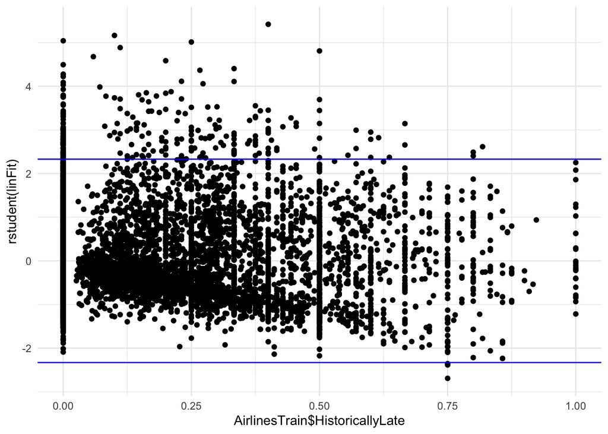

```r
ggplot() + aes(x=AirlinesTrain$HistoricallyLate, y=rstudent(linFit)) + geom_point() +
  geom_hline(yintercept=c(-2.33,2.33), color="blue") + theme_minimal()
```

Some outliers in the top (real delays bigger than expected)

Diagnostic plots: residuals, fitted values, Cook’s distance, and leverage

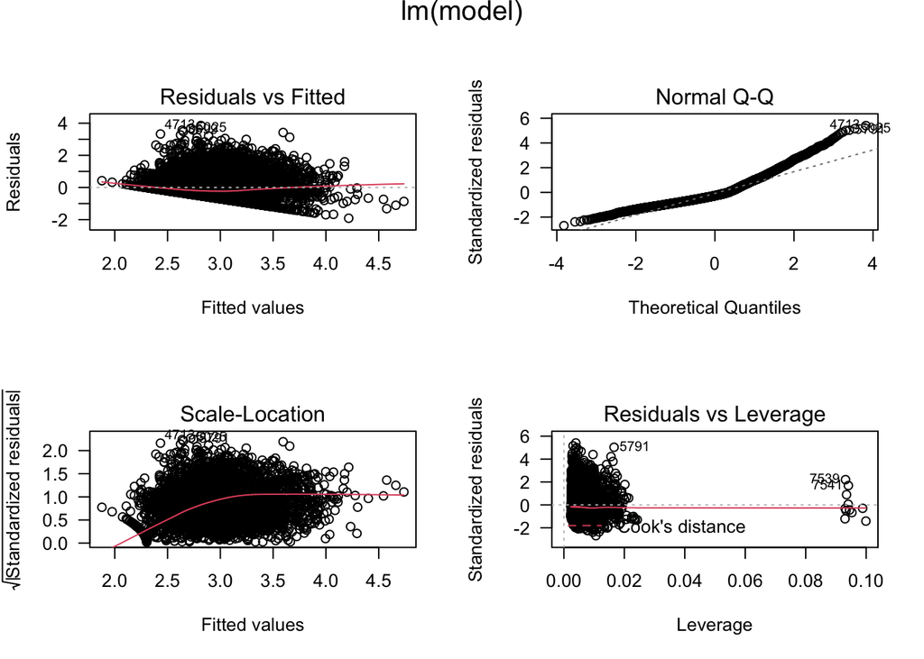

```r
opar <- par(mfrow = c(2,2), oma = c(0, 0, 1.1, 0))
plot(linFit, las = 1)
```

Some outliers

Prediction

```r
prLM <- predict(linFit, newdata=AirlinesTest)

cor(log(AirlinesTest$TotalDelay+10), prLM)^2
```

```
## [1] 0.1758848
```

```r
mean(abs(log(AirlinesTest$TotalDelay+10)- prLM)/log(AirlinesTest$TotalDelay+10))
```

```
## [1] 0.1866181
```

## Huber estimation

```r
linfit.huber <- rlm(model, data=AirlinesTrain)
summary(linfit.huber)
```

```
##
## Call: rlm(formula = model, data = AirlinesTrain)
## Residuals:
##     Min      1Q  Median      3Q     Max
## -1.7735 -0.3876 -0.1187  0.4518  3.9332
##
## Coefficients:
##                            Value   Std. Error t value
## (Intercept)                 1.3468  0.1426     9.4445
## FlightATL-ORD              -0.0650  0.0311    -2.0867
## FlightLAX-ATL              -0.0534  0.0281    -1.8986
## FlightLAX-ORD              -0.3038  0.1922    -1.5807
## FlightORD-ATL              -0.0666  0.0326    -2.0430
## FlightORD-LAX              -0.1958  0.1922    -1.0187
## CarrierAmerican Airlines    0.2876  0.1975     1.4558
## CarrierDelta Air Lines      0.0369  0.0493     0.7477
## CarrierExpressJet Airlines  0.1336  0.0920     1.4528
## CarrierSkyWest Airlines     0.3112  0.0687     4.5302
## CarrierSouthwest Airlines  -0.0055  0.0552    -0.0999
## CarrierUnited Airlines      0.4176  0.1964     2.1262
## CarrierVirgin America       0.2746  0.2006     1.3689
## MonthJuly                  -0.0861  0.0184    -4.6782
## MonthJune                   0.0014  0.0191     0.0750
## DayOfWeekMonday             0.0111  0.0273     0.4068
## DayOfWeekSaturday          -0.0557  0.0292    -1.9083
## DayOfWeekSunday            -0.0777  0.0276    -2.8171
## DayOfWeekThursday           0.0355  0.0274     1.2975
## DayOfWeekTuesday           -0.0183  0.0282    -0.6479
## DayOfWeekWednesday          0.0438  0.0276     1.5882
## NumPrevFlights              0.0186  0.0071     2.6039
## PrevFlightGap              -0.0002  0.0001    -2.1542
## HistoricallyLate            1.3049  0.0471    27.6885
## InsufficientHistory         0.3511  0.0227    15.4465
## OriginInVolume              0.0916  0.0684     1.3397
## OriginOutVolume             0.3970  0.0896     4.4305
## DestInVolume                0.2033  0.0910     2.2338
## DestOutVolume               0.0666  0.0328     2.0297
## OriginPrecip                0.0005  0.0001     5.8418
## OriginAvgWind              -0.0090  0.0042    -2.1375
## OriginWindGust              0.0156  0.0019     8.2998
## OriginFog                   0.0286  0.0236     1.2125
## OriginThunder               0.0373  0.0462     0.8064
## DestPrecip                  0.0007  0.0001     7.2546
## DestAvgWind                -0.0127  0.0042    -3.0032
## DestWindGust                0.0096  0.0019     5.1165
## DestFog                    -0.0420  0.0238    -1.7662
## DestThunder                 0.1099  0.0464     2.3686
##
## Residual standard error: 0.5992 on 7467 degrees of freedom
```

Prediction

```r
prHuber <- predict(linfit.huber, newdata=AirlinesTest)

cor(log(AirlinesTest$TotalDelay+10), prHuber)^2
```

```
## [1] 0.1709775
```

```r
mean(abs(log(AirlinesTest$TotalDelay+10)- prHuber)/log(AirlinesTest$TotalDelay+10))
```

```
## [1] 0.1743368
```

## Bi-square estimation

```r
linfit.bisquare <- rlm(model, data=AirlinesTrain, psi = psi.bisquare)
summary(linfit.bisquare)
```

```
##
## Call: rlm(formula = model, data = AirlinesTrain, psi = psi.bisquare)
## Residuals:
##      Min       1Q   Median       3Q      Max
## -1.69758 -0.35719 -0.09165  0.48451  3.96913
##
## Coefficients:
##                            Value   Std. Error t value
## (Intercept)                 1.3780  0.1422     9.6902
## FlightATL-ORD              -0.0860  0.0311    -2.7686
## FlightLAX-ATL              -0.0631  0.0281    -2.2505
## FlightLAX-ORD              -0.3417  0.1916    -1.7829
## FlightORD-ATL              -0.0973  0.0325    -2.9950
## FlightORD-LAX              -0.2427  0.1916    -1.2665
## CarrierAmerican Airlines    0.3208  0.1970     1.6288
## CarrierDelta Air Lines      0.0369  0.0492     0.7496
## CarrierExpressJet Airlines  0.1059  0.0917     1.1545
## CarrierSkyWest Airlines     0.3301  0.0685     4.8184
## CarrierSouthwest Airlines  -0.0173  0.0551    -0.3143
## CarrierUnited Airlines      0.4456  0.1958     2.2750
## CarrierVirgin America       0.3071  0.2000     1.5352
## MonthJuly                  -0.0732  0.0183    -3.9902
## MonthJune                   0.0133  0.0190     0.6993
## DayOfWeekMonday             0.0243  0.0272     0.8947
## DayOfWeekSaturday          -0.0432  0.0291    -1.4838
## DayOfWeekSunday            -0.0630  0.0275    -2.2912
## DayOfWeekThursday           0.0307  0.0273     1.1248
## DayOfWeekTuesday           -0.0048  0.0282    -0.1700
## DayOfWeekWednesday          0.0414  0.0275     1.5072
## NumPrevFlights              0.0158  0.0071     2.2244
## PrevFlightGap              -0.0003  0.0001    -2.8800
## HistoricallyLate            1.2896  0.0470    27.4415
## InsufficientHistory         0.3377  0.0227    14.8970
## OriginInVolume              0.1052  0.0682     1.5422
## OriginOutVolume             0.4067  0.0894     4.5512
## DestInVolume                0.1591  0.0907     1.7538
## DestOutVolume               0.0724  0.0327     2.2144
## OriginPrecip                0.0005  0.0001     5.3292
## OriginAvgWind              -0.0080  0.0042    -1.9086
## OriginWindGust              0.0140  0.0019     7.4612
## OriginFog                   0.0299  0.0235     1.2720
## OriginThunder               0.0446  0.0461     0.9686
## DestPrecip                  0.0006  0.0001     6.3447
## DestAvgWind                -0.0118  0.0042    -2.8086
## DestWindGust                0.0091  0.0019     4.8261
## DestFog                    -0.0418  0.0237    -1.7625
## DestThunder                 0.1142  0.0463     2.4690
##
## Residual standard error: 0.572 on 7467 degrees of freedom
```

Prediction

```r
prBi <- predict(linfit.bisquare, newdata=AirlinesTest)

cor(log(AirlinesTest$TotalDelay+10), prBi)^2
```

```
## [1] 0.1673918
```

```r
mean(abs(log(AirlinesTest$TotalDelay+10)- prBi)/log(AirlinesTest$TotalDelay+10))
```

```
## [1] 0.1706238
```

Some improvement

When comparing the results of OLS regression with robust regression, if the results are very different, better to use the results from the robust regression: more reliable

Large differences suggest that the model parameters are being highly influenced by outliers

Different loss functions have advantages and drawbacks. Huber weights can have difficulties with severe outliers, and bisquare weights can have difficulties converging or may yield multiple solutions

# An introduction to Caret

Highly recommended package

- to evaluate performance and calibrate sensitive parameters
- to choose the best model across these parameters
- to estimate model performance from a training set
- Main function: train()

tidymodels is the tidy version of caret (collection of packages for modelling)

These are the models for regression and classification:

```r
names(getModelInfo())
```

```
##   [1] "ada"                 "AdaBag"              "AdaBoost.M1"
##   [4] "adaboost"            "amdai"               "ANFIS"
##   [7] "avNNet"              "awnb"                "awtan"
##  [10] "bag"                 "bagEarth"            "bagEarthGCV"
##  [13] "bagFDA"              "bagFDAGCV"           "bam"
##  [16] "bartMachine"         "bayesglm"            "binda"
##  [19] "blackboost"          "blasso"              "blassoAveraged"
##  [22] "bridge"              "brnn"                "BstLm"
##  [25] "bstSm"               "bstTree"             "C5.0"
##  [28] "C5.0Cost"            "C5.0Rules"           "C5.0Tree"
##  [31] "cforest"             "chaid"               "CSimca"
##  [34] "ctree"               "ctree2"              "cubist"
##  [37] "dda"                 "deepboost"           "DENFIS"
##  [40] "dnn"                 "dwdLinear"           "dwdPoly"
##  [43] "dwdRadial"           "earth"               "elm"
```

[output cut: 65 more lines]

## Tuning

Each model can be automatically tuned and evaluated

Example: use 5 repeats of 10-fold cross validation

```r
ctrl <- trainControl(method = "repeatedcv",
                     repeats = 5,
                     number = 10)
```

We can also choose bootstrap, LOOCV, etc.

```r
ctrl <- trainControl(method = "none")
```

## The train function

This function sets up a grid of tuning parameters for a number of classification and regression routines, fits each model and calculates a resampling based performance measure

Let’s first save our predictions and real observations in a data frame

```r
test_results <- data.frame(TotalDelay = log(AirlinesTest$TotalDelay+10))

observed = log(AirlinesTest$TotalDelay+10)
```

Linear regression with Caret:

```r
lm_tune <- train(log(TotalDelay+10) ~ .,
                 data = AirlinesTrain,
                 method = "lm",
                 preProc=c('scale', 'center'),
                 trControl = ctrl)
```

Prediction

```r
test_results$lm <- predict(lm_tune, AirlinesTest)

postResample(pred = test_results$lm,  obs = observed)
```

```
##      RMSE  Rsquared       MAE
## 0.7303670 0.1758848 0.5624128
```

Plot

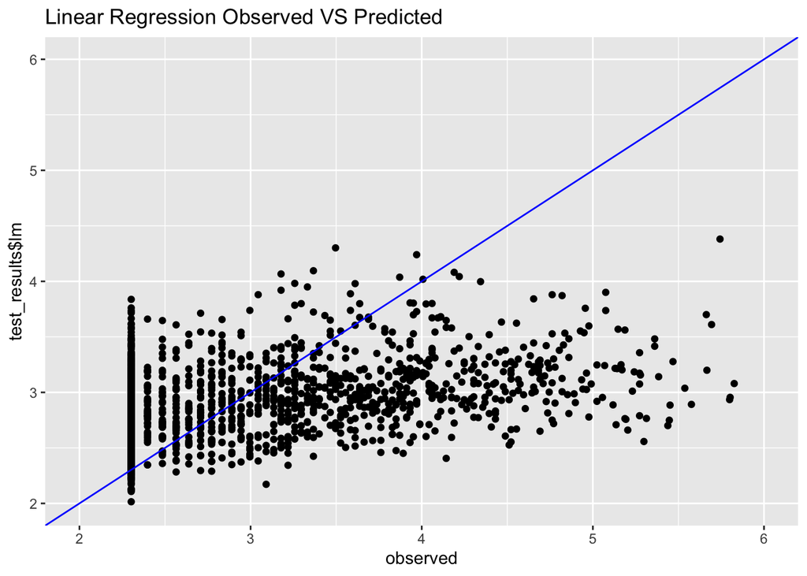

```r
qplot(observed, test_results$lm) +
  lims(x = c(2, 6), y = c(2, 6)) +
  geom_abline(intercept = 0, slope = 1, colour = "blue") +
  ggtitle("Linear Regression Observed VS Predicted")
```

Robust regression with Caret

```r
ctrl <- trainControl(method = "repeatedcv",
                     number = 5)

# take care: rlm does not work very well with categorical variables
rlm_tune <- train(log(TotalDelay+10) ~ .,
                  data = AirlinesTrain[,c(-1,-2,-3,-4)],
                  method = "rlm",
                  preProc=c('scale', 'center'),
                  trControl = ctrl)

rlm_tune
```

```
## Robust Linear Model
##
## 7506 samples
##   18 predictor
##
## Pre-processing: scaled (18), centered (18)
## Resampling: Cross-Validated (5 fold, repeated 1 times)
## Summary of sample sizes: 6004, 6005, 6005, 6004, 6006
## Resampling results across tuning parameters:
##
##   intercept  psi           RMSE       Rsquared   MAE
##   FALSE      psi.huber     2.9698422  0.1603180  2.8801835
##   FALSE      psi.hampel    2.9698339  0.1602518  2.8801674
##   FALSE      psi.bisquare  2.9698180  0.1603581  2.8801599
##    TRUE      psi.huber     0.7297863  0.1598147  0.5408938
##    TRUE      psi.hampel    0.7250118  0.1604603  0.5503373
##    TRUE      psi.bisquare  0.7342867  0.1590506  0.5361208
##
## RMSE was used to select the optimal model using the smallest value.
## The final values used for the model were intercept = TRUE and psi = psi.hampel.
```

Numerically unstable…

Predict and plot

```r
test_results$rlm <- predict(rlm_tune, AirlinesTest[,c(-1,-2,-3,-4)])
postResample(pred = test_results$rlm,  obs = observed)
```

```
##      RMSE  Rsquared       MAE
## 0.7403310 0.1561499 0.5615268
```

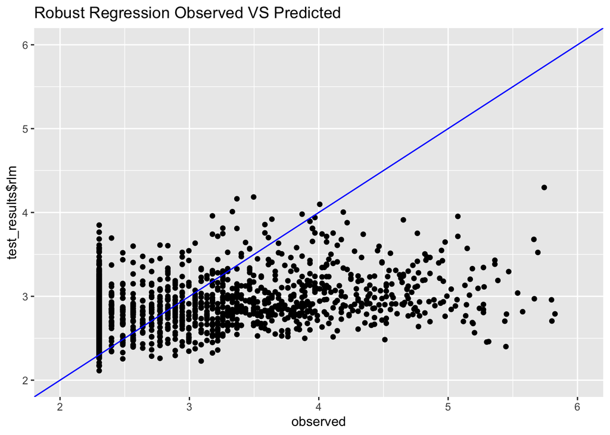

```r
qplot(observed, test_results$rlm) +
  lims(x = c(2, 6), y = c(2, 6)) +
  geom_abline(intercept = 0, slope = 1, colour = "blue") +
  ggtitle("Robust Regression Observed VS Predicted")
```